# A Model of Representativity with Changing Beliefs

Groups of people often choose representatives to decide issues on their behalf. While a representative ideally stays aligned with the beliefs of their constituents throughout their tenure, group beliefs may change more quickly than representatives are selected; creating a potential for misrepresentation that we call representative drift. For example, a scientist committed to a particular theory may be chosen to serve as a program officer, allocating funds, and remain loyal to their theory while the field moves on. An employee may be chosen to advocate for their colleagues when choosing an insurance plan for their company, but become convinced by management to diverge from what their colleagues believe is the best plan. Or, a homeowner may be chosen to represent their neighborhood in a public council on solar panel regulations, but eventually drift to choose regulations that benefit a subset of neighbors at the expense of all others. Representative drift abounds. To gain intuition about the tendency of a group to become misrepresented over time, we developed a simple computational model from a few motivating assumptions:

1. Group members live in a static social network.
2. Representatives are chosen from the members of the group.
3. The group changes beliefs more quickly than they choose representatives
4. Members endogenously update their beliefs over time as a function of the average beliefs of a reference group.

### Results

```python
from super_fun_cool_model import Model,runExperiment,visualizeExperiment
```

```python
# increasing size
E1A = runExperiment(N=100,M=10,num_attributes=10,P=0.2,steps=10,peer_effect=0.5,Wp=0.1,number_of_runs=30,who_influences='all peers')
E1B = runExperiment(N=500,M=10,num_attributes=10,P=0.2,steps=10,peer_effect=0.5,Wp=0.1,number_of_runs=30,who_influences='all peers')
E1C = runExperiment(N=1000,M=10,num_attributes=10,P=0.2,steps=10,peer_effect=0.5,Wp=0.1,number_of_runs=30,who_influences='all peers')
```

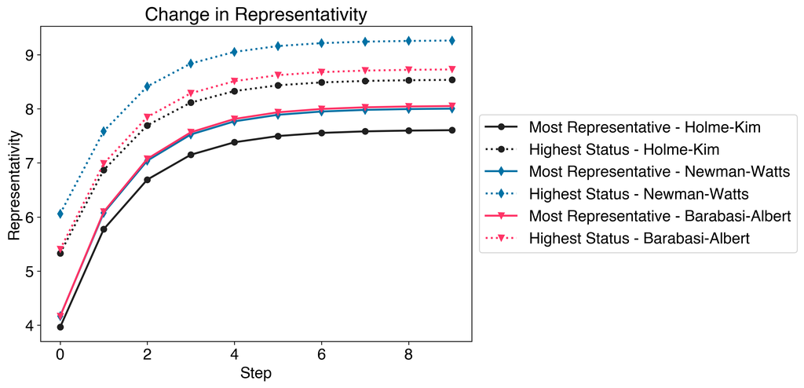

```python
visualizeExperiment(E1A)
```

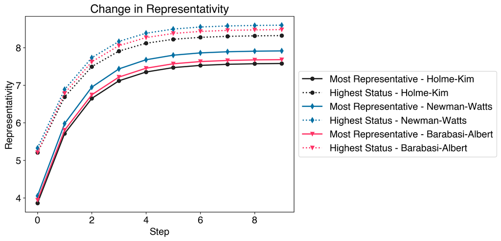

```python
visualizeExperiment(E1B)
```

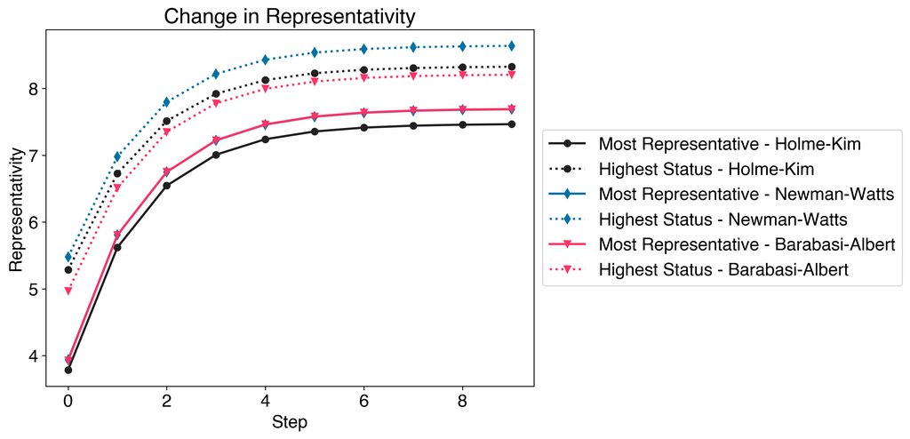

```python
visualizeExperiment(E1C)
```

```python
E4A = runExperiment(N=100,M=10,num_attributes=10,P=0.2,steps=20,peer_effect=0.2,Wp=0.1,number_of_runs=30,who_influences ='higher status peers')
E4B = runExperiment(N=100,M=10,num_attributes=10,P=0.2,steps=20,peer_effect=0.8,Wp=0.1,number_of_runs=30,who_influences ='higher status peers')

E4C = runExperiment(N=100,M=10,num_attributes=10,P=0.2,steps=20,peer_effect=0.2,Wp=0.1,number_of_runs=30, who_influences = 'all peers')
E4D = runExperiment(N=100,M=10,num_attributes=10,P=0.2,steps=20,peer_effect=0.8,Wp=0.1,number_of_runs=30, who_influences = 'all peers')
```

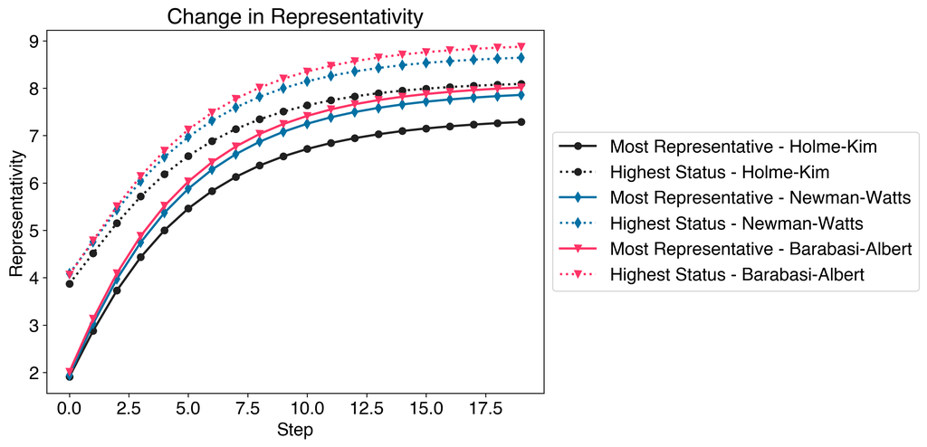

```python
visualizeExperiment(E4A)
```

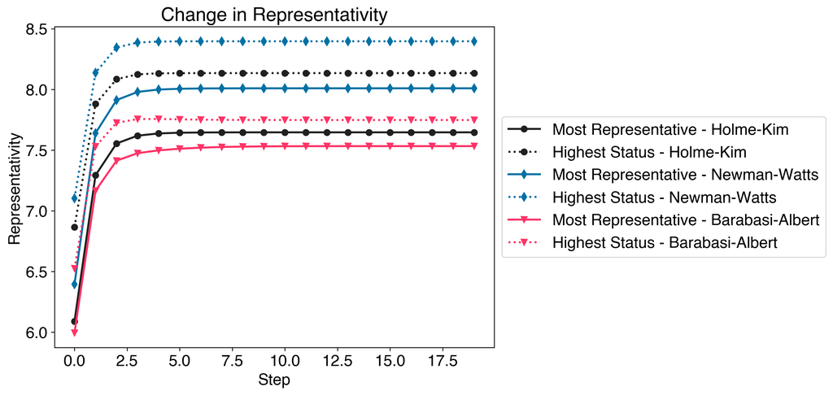

```python
visualizeExperiment(E4B)
```

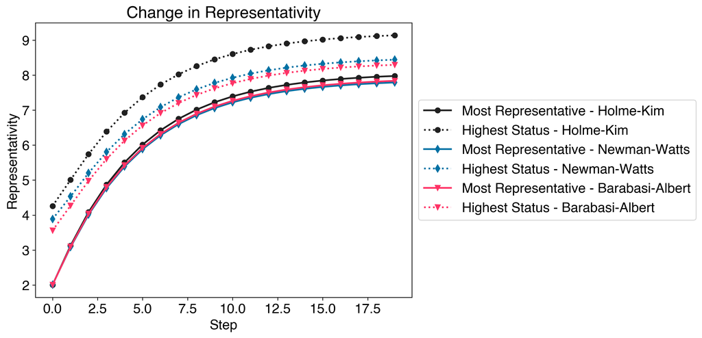

```python
visualizeExperiment(E4C)
```

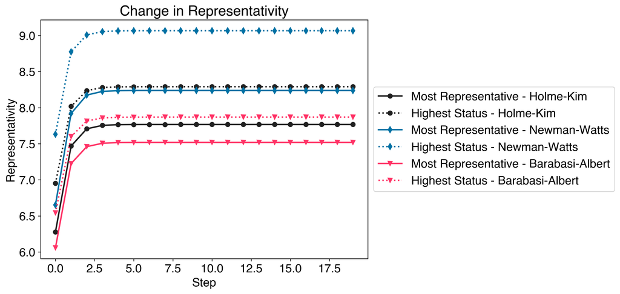

```python
visualizeExperiment(E4D)
```

```python
E5A = runExperiment(N=100,M=50,num_attributes=10,P=0.2,steps=10,peer_effect=0.2,Wp=0.1,number_of_runs=30,who_influences ='higher status peers')
E5B = runExperiment(N=100,M=50,num_attributes=10,P=0.2,steps=10,peer_effect=0.8,Wp=0.1,number_of_runs=30,who_influences ='higher status peers')

E5C = runExperiment(N=100,M=50,num_attributes=10,P=0.2,steps=10,peer_effect=0.2,Wp=0.1,number_of_runs=30, who_influences = 'all peers')
E5D = runExperiment(N=100,M=50,num_attributes=10,P=0.2,steps=10,peer_effect=0.8,Wp=0.1,number_of_runs=30, who_influences = 'all peers')
```

# Future Directions

We showed above that our model can generate straightforward insights about representative drift, although our analysis has been limited and none of our results is particularly surprising. In addition to considering a wider range of parameter combinations, there are several ways to extend this work. First, representation and social influence may vary across different sectors of the economy. We may similarly expect to see cross-cultural variation, for example between individualistic and collectivistic nations. In individualistic societies, agents tend to select representatives based on individual opinions and personal relationships, whereas, in collectivistic societies, representatives may be self-appointed or chosen for their high-status within the group. Adding sectoral and cultural nuance to our model should therefore help us produce better policy recommendations. While we considered the effect of endogenously changing beliefs on representative drift, we omitted exogenous factors such as the effect of media, or heterogeneous shocks to members' beliefs. In addition, our evaluation of representative drift is fairly naive. It is not differences in beliefs that matter most, but the decisions that emerge from those differences which ultimately affect the lives of group members. We could address this by having representatives select from an exogenously provided set of policies, and by considering different forms of compliance. For example, members could opt out of policies chosen by their representative that they feel are particularly bad, which under some conditions would increase the marginal benefits of the compliance for those who prefer the chosen policy. Another unexplored part of our model is the effect of group diversity on representative drift under different conditions. We initially considered representing beliefs as a random draw from a multinomial distribution, which allows for straightforward tuning of group diversity via the distribution's entropy: $H \approx \frac{k-1}{2} \log_2 (2 \pi n e) + \frac{1}{2} \sum_{i=1} k \log_2 p_i$ where k is the number of possible outcomes, n is the number of trials, p is the probability of each outcome. But this approach makes a less realistic assumption about the structure of beliefs, and so some may prefer to directly manipulate the covariance matrix used to generate the multivariate normal distribution we actually use, to change the spread of beliefs in the population. Similarly, we kept a static network to simplify our model, but this is certainly not what empirical networks look like, and incorporating structural change, growth and exit from the group could lead to interesting results. The most important question is ultimately how we can reduce drift or mitigate the impact of a chosen representative when quick reselection is impractical. This could be accomplished through incentives, by manipulating the network to control how beliefs change, or through more complex strategies for selecting representatives.

# References

1. Barabási, A. L., & Albert, R. (1999). Emergence of scaling in random networks. Science, 286(5439), 509-512.
2. Watts, D. J., & Strogatz, S. H. (1998). Collective dynamics of ‘small-world’networks. Nature, 393(6684), 440-442.
3. Newman, M. E., & Watts, D. J. (1999). Scaling and percolation in the small-world network model. Physical Review E, 60(6), 7332.
4. Holme, P., & Kim, B. J. (2002). Growing scale-free networks with tunable clustering. Physical review E, 65(2), 026107.
5. Bonacich, P. (1987). Power and centrality: A family of measures. American Journal of Sociology, 92(5), 1170-1182.
6. Manski, C. F. (1993). Identification of endogenous social effects: The reflection problem. The Review of Economic Studies, 60(3), 531-542.
7. Ugander, J., Backstrom, L., Marlow, C., & Kleinberg, J. (2012). Structural diversity in social contagion. Proceedings of the National Academy of Sciences, 109(16), 5962-5966.